# R Notebook

# MVP

Using the dataset austen_books() from the package janeaustenr.

```r
library(tidyverse)
library(tidytext)
library(textdata)
library(janeaustenr)
```

```r
titles <- c("Pride & Prejudice", "Sense & Sensibility")
books <- list(prideprejudice, sensesensibility)

books <- purrr::map_chr(books, paste, collapse = " ")
```

[output not shown]

[output cut: 990 more lines]

## Find the most common words in both Pride & Prejudice and Sense & Sensibility.

```r
two_books %>%
  count(title, word) %>%
  group_by(title) %>%
  slice_max(n, n = 3)
```

| title | word | n |
| --- | --- | --- |
| Pride & Prejudice | the | 4331 |
| Pride & Prejudice | to | 4162 |
| Pride & Prejudice | of | 3610 |
| Sense & Sensibility | to | 4116 |
| Sense & Sensibility | the | 4105 |
| Sense & Sensibility | of | 3571 |

```r
NA
```

The most common words across both books are “the”, “to” and “of.

## Find the most common words in both Pride & Prejudice and Sense & Sensibility, not including stop words.

```r
two_books %>%
  anti_join(stop_words) %>%
    count(title, word) %>%
  group_by(title) %>%
  slice_max(n, n = 3)
```

| title | word | n |
| --- | --- | --- |
| Pride & Prejudice | elizabeth | 597 |
| Pride & Prejudice | darcy | 373 |
| Pride & Prejudice | bennet | 294 |
| Sense & Sensibility | elinor | 623 |
| Sense & Sensibility | marianne | 492 |
| Sense & Sensibility | time | 239 |

The most common words (excluding stop words) are “Elizabeth”, “Darcy” and “Bennet” in Pride& Prejudice, and “Elinor”, “Marianne” and “Time” in Sense & Sensibility.

## Find the most common sentiment words in both Pride & Prejudice and Sense & Sensibility.

```r
# using bing list as sentiment words
lexicon_bing()
```

| word | sentiment |
| --- | --- |
| 2-faced | negative |
| 2-faces | negative |
| abnormal | negative |
| abolish | negative |
| abominable | negative |
| abominably | negative |
| abominate | negative |
| abomination | negative |
| abort | negative |
| aborted | negative |

[output cut: 990 more lines]

```r
two_books %>%
  inner_join(lexicon_bing()) %>%
  group_by(title, word) %>%
  summarise(word_count = n()) %>%
  slice_max(word_count, n = 3)
```

| title | word | word_count |
| --- | --- | --- |
| Pride & Prejudice | miss | 283 |
| Pride & Prejudice | well | 224 |
| Pride & Prejudice | good | 200 |
| Sense & Sensibility | well | 240 |
| Sense & Sensibility | miss | 210 |
| Sense & Sensibility | good | 177 |

The most common sentiment words from P&P are “miss”, “well” and “good” and for S&S are “well”, “miss” and “good”.

# Extension

Taking your results above. Can you create a plot which visualises the differences between the books?

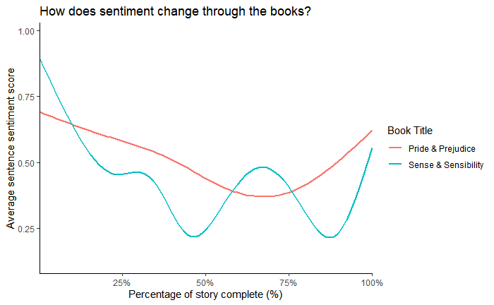

S&S starts off more positive than P&P but sharply decreases before rising again at 50% of the book. It rises a bit then decreases again before finally rising towards the end of the book. P&P drops more slowly as the book progresses with a low-point at around 70% of the story completed, before rising again continuously until the end of the book.

Interestingly, both books start happier than they end (in terms of sentimental words used!)